# Interactive Stock Chart Using Shiny and Plotly R Packages

TMC  
January 06, 2017

### Overview (1/2)

#### This shiny application allows the user to select a stock or index for a single year and plot the daily price data as a"candlestick" chart. Additionally, two technical indicators can be selected and superimposed on the price chart.

### Overview (2/2)

The application uses drop down selection boxes when there are several choices the user can make.

It also uses radio button selection groups when the user can select only one of the choices provided.

The chart itself is a plotly interactive chart that receives as input the selections make by the user. Hovering over a bar (the day's price data) will display the data for that day:

- High, Low, Open, Close Prices
- “Fast” MA value, “Slow” MA value

### Daily Price Data - Candlestick Chart

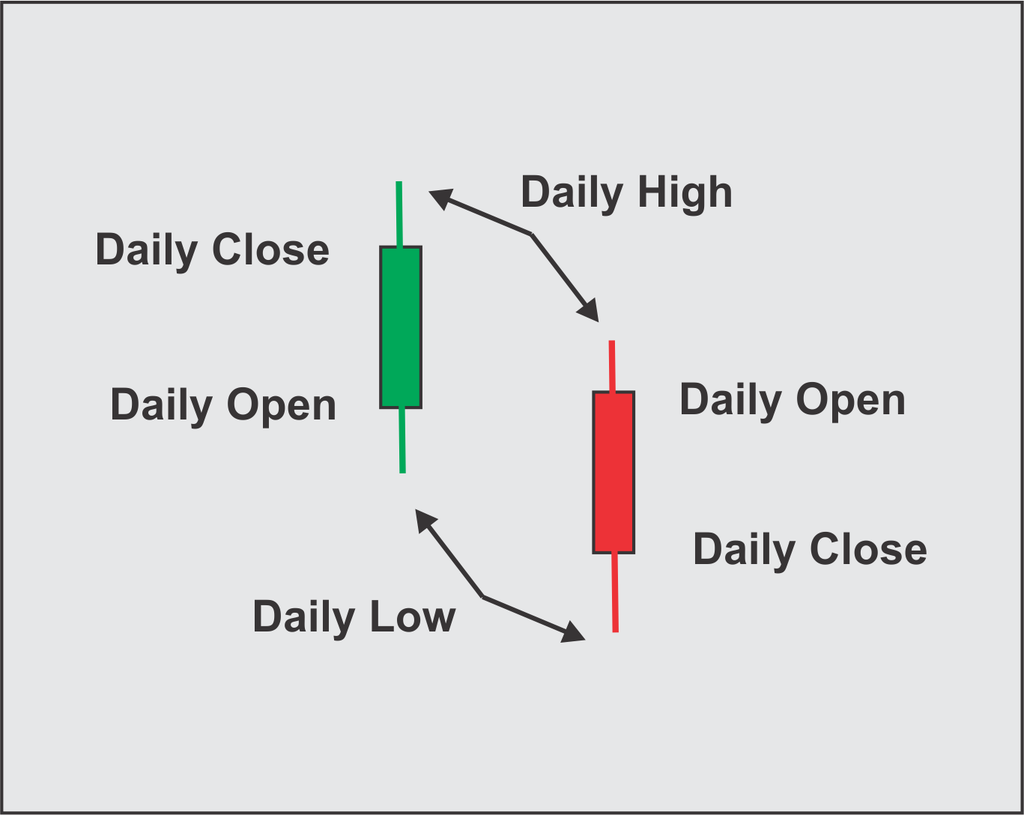

*Candlesticks are an improvement over a traditional chart. The graphical enhancements allow the user to quickly pick up key info on the day's price movement.*

Four prices for each day are plotted as a set of two prices using different graphic elements:

- The Highest and Lowest price for the day. A thin line is drawn extending from the High price to the Low price.
- The Open and Close prices for the day. A filled rectangle extending between the Open and Close prices.
- The color of the H/L line and the fill of the O/C rectangle is determined by the relationship of the Open and Close prices: Green if the Close price is greater than the Open price. Otherwise, the color is Red.

### Technical Indicators (2/3)

Two types of moving averages are available for each window length:

- Simple moving average - Each price in the window has the same “weight”. Each price is treated equally to all other prices.
- Weighted moving average - The more recent prices have a greater weight than the early prices in the window. Current prices have a greater impact on the average than older prices. This type of average is also called an “Exponential” moving average.

### Technical Indicators (3/3)

The combination of these two indicators *generally* are used to identify an up trend in the stock's price. An old rule of thumb is that when the “fast” moving average is above the “slow” moving average, the stock is trending up. The opposite indicates the stock trending down.

**This is a general indication of the stock's trend. It does not hold in all cases and is not a reliable signal on its own to enter of exit trades.**